# ggplot2 tutorial

Ethel Ruan

2017年3月9日

# 使用ggplot2进行高级绘图

## 语法

图是由`+`号串联函数而创建的，每个函数修改属于自己的部分

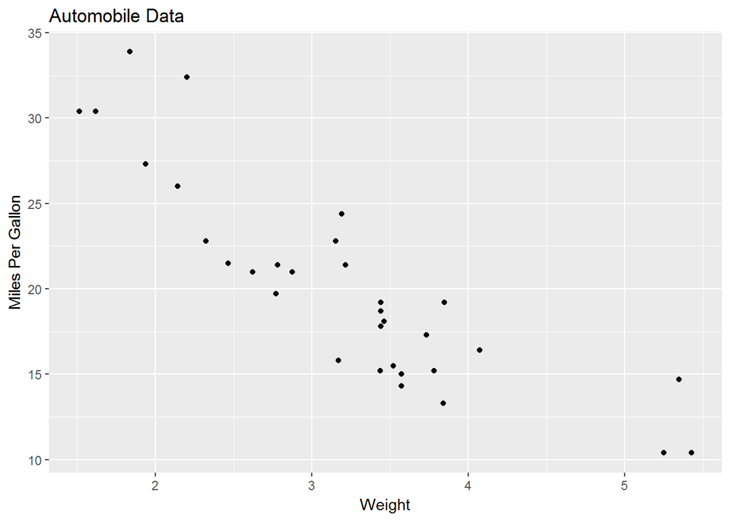

```r
ggplot (data = mtcars) +
  aes(x = wt,y = mpg) + geom_point() +
  labs(title = "Automobile Data",x="Weight",y = "Miles Per Gallon")
```

- `ggplot()`初始化图形并指定要用到的数据来源和变量
- `aes()`,aesthetics,如何用视觉形式呈现信息，指定每个变量扮演的角色
- 使用一个或者多个几何函数向图中添加几何对象，包括点、线、条、箱线图和阴影区域

例如：

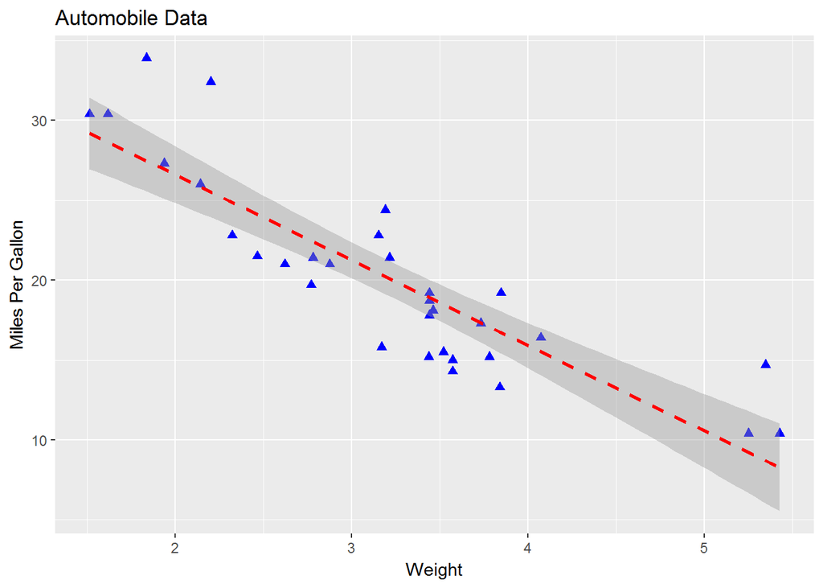

```r
ggplot(data = mtcars,aes(x=wt,y=mpg)) +
  geom_point(pch = 17,color = "blue",size = 2) +
  geom_smooth(method = "lm", color = "red", linetype = 2) +
  labs(title = "Automobile Data",x="Weight",y = "Miles Per Gallon")
```

- `geom_point()`生成了点，三角形形状（pch=17），点的尺寸为2倍
- `geom_smooth()`增加了一条“平滑”曲线，平滑曲线包括95%的置信区间（较暗地带）内。

## 分组和小面化（faceting）

- 分组：一个图形中显示两组或多组观察结果
- 小面化：单独、并排的图形上现实观察组

### 示例

- 先查看分和面，首先，将am、vs、cyl变量转化为因子

```r
mtcars$am <- factor(mtcars$am, levels = c(0,1), labels = c("Automatic","Manual"))
mtcars$vs <- factor(mtcars$vs, levels = c(0,1), labels = c("V-Engine","Straight Engine"))
mtcars$cyl <- factor(mtcars$cyl)
```

- 然后画图

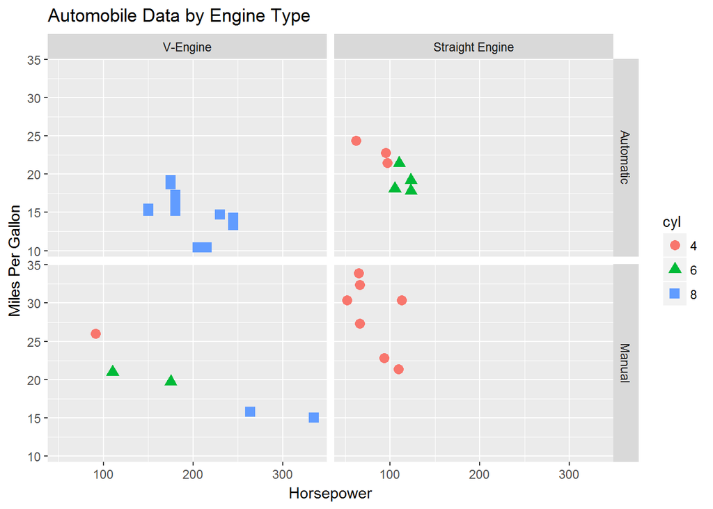

```r
ggplot(mtcars, aes(x = hp, y = mpg, shape = cyl, color = cyl)) +
  geom_point(size = 3) +
  facet_grid(am~vs) +
  labs(title = "Automobile Data by Engine Type", x = "Horsepower", y = "Miles Per Gallon")
```

效果图包含 **变速箱类型**（**am** = auto）和**发动机装置**（**vs** = V）每个组合的分离散点图。每个店的颜色和形状表示发动机气缸（**cyl**）的数量 **am和vs是刻面变量，cyl是分组变量**

### 学习流程

- [ ] 介绍几何函数以及能够创建的图形类型
- [ ] 详细了解aes()函数，并用它来对数据分组
- [ ] 考虑刻面和网格图形的简历
- [ ] 调整图形的外观，修改坐标轴、图例、配色和注释

## 用几何函数指定图的类型

| 函数 | 添加 | 选项 |
| --- | --- | --- |
| geom_bar | 条形图 | color,fill,alpha |
| geom_boxplot | 箱线图 | color,fill,alpha,notchmwidth |
| geom_density | 密度图 | color,fill,alpha,linetype |
| geom_histogram | 直方图 | color,fill,alpha,linetype,binwidth |
| geom_hline | 水平线 | color,fill,alpha,shape |
| geom_jiter | 抖动点 | color,fill,alpha,shape |
| geom_line | 线图 | color,alpha,linetype,size |
| geom_point | 散点图 | color,alpha,shape,size |
| geom_rug | 地毯图 | color,side |
| geom_smooth | 拟合曲线 | method,formula,color,fill,linetype,size |
| geom_text | 文字注解 | see help |
| geom_violin | 小提琴图 | color,fill,alpha,linetype |
| geom_vline | 垂线 | color,fill,linetype,size |

### 示例

```r
library(lattice)
data(siger,package = "lattice")
```

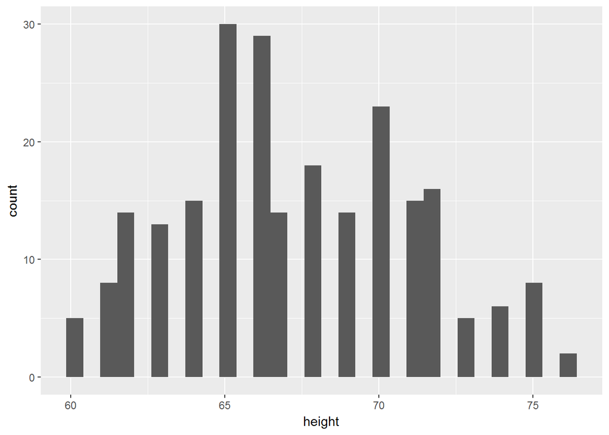

```r
ggplot(singer,aes(x=height)) +
  geom_histogram()
```

产生直方图

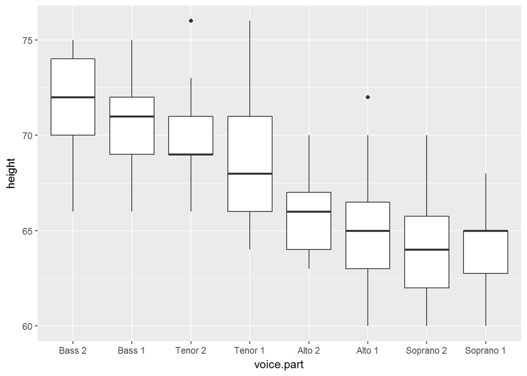

```r
ggplot(singer,aes(x=voice.part,y=height)) +
  geom_boxplot()
```

产生箱线图，可以看出低音歌唱家比高音歌唱家身高更高。虽然性别没有测量在内，但它也许起了很大的作用

此外，创建直方图时，只有变量X是需要指定的，Y变量如果没有指定，是默认对Y轴变量计数。 但是创建箱线图时，变量X和Y都需要指定的。

## 几何函数的常见参数

| 参数 | 详述 |
| --- | --- |
| color | 对点、线、填充区域的边界进行着色 |
| fill | 对填充区域着色 |
| alpha | 透明度 |
| linetype | 线条 |
| size | 点的尺寸和线的宽度 |
| shape | 点的形状 |
| position | 绘制条形图和点等对象的位置。对条形图来说，“dodge”将分组条形并排，“stack”堆叠分组条形图，“fill”垂直并等高堆叠分组条形图；而对于点来说，“jitter”指减少点重叠 |
| binwidth | 直方图的宽度 |
| notch | 方块图是否应为缺口 |
| sides | 地毯图的安置：b/l/t/r/bl等 |
| width | 箱线图的宽度 |

### 示例

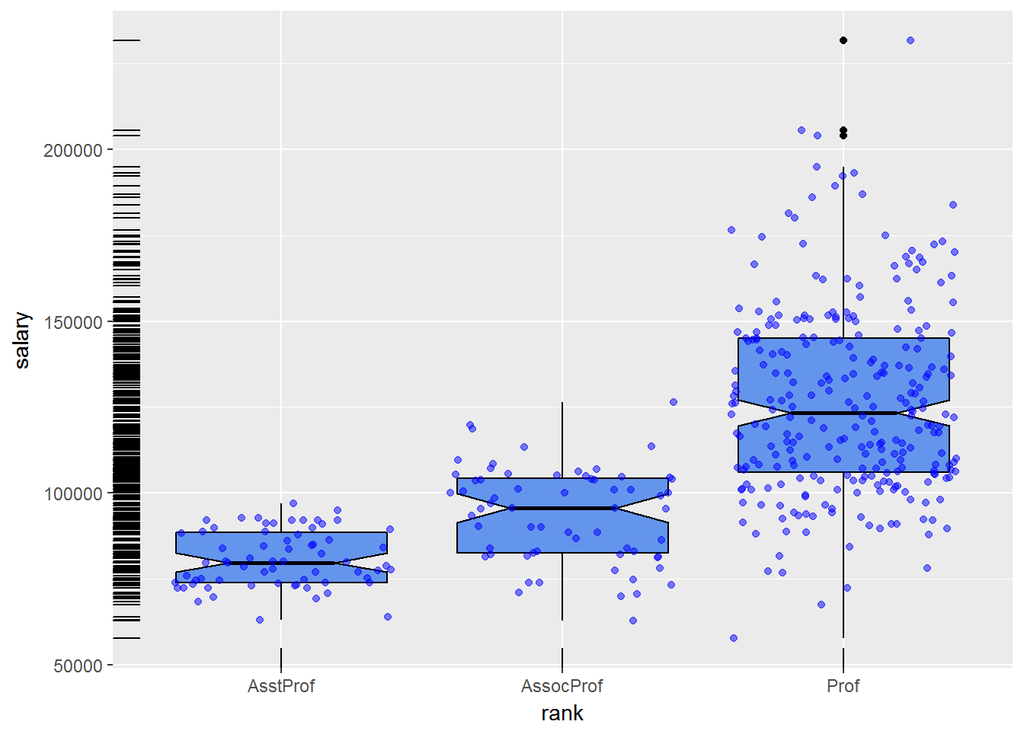

```r
data(Salaries,package = "car")
ggplot(Salaries,aes(x = rank,y = salary)) +
  geom_boxplot(fill = "cornflowerblue",
  color = "black", notch = TRUE) +
  geom_point(position = "jitter", color = "blue", alpha = .5) +
  geom_rug(side = "1", color = "black")
```

该图显示了不同学术地位对应薪水的缺口箱线图。实际的观察值（教师）是重叠的，因而给予一定的透明度以免遮挡箱线图，并抖动减少重叠。最后，地毯图设置在左侧以只是薪水的一般扩散。 图中，可以发现助教、副教、和教授的工资有显著的不同，其中至少有一位教授的薪水低于副教，而有三位教授的公司非常高，成为了异常点（教授箱线图的黑点）

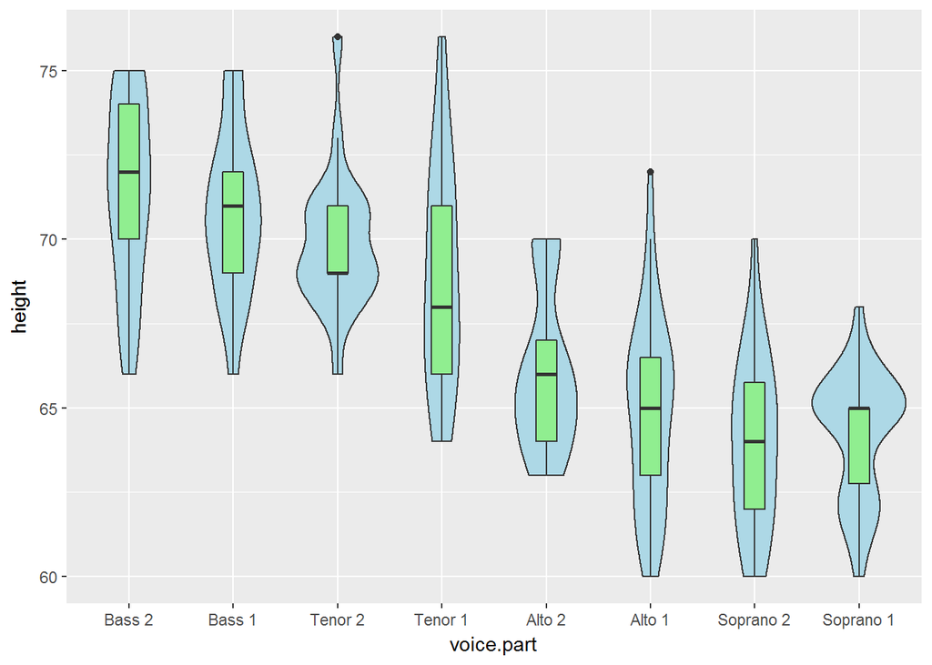

```r
data(singer,package = "lattice")
ggplot(singer,aes(x=voice.part, y = height)) +
  geom_violin(fill = "lightblue") +
  geom_boxplot(fill = "lightgreen", width = 0.2)
```

该图是结合了箱线图和小提琴图，箱线图展示了在歌手数据框中每个音部的25%，50%，75%分位数的得分和任意的异常值。对于每个声部身高范围上的得分分布，小提琴图的展示更加直观。

## 分组

- 在R中，组通常用分类变量的水平（因子）来定义。
- 分组是通过ggplot2图将一个或者多个带有诸如形状、颜色、填充、尺寸和线类型的视觉特征的分组变量来完成的。
- `aes()`函数负责分配变量，所以这是一个分配分组变量的地方。

用分组来探讨Salaries数据集。数据框包含08~09学年大学教授的薪水，变量包括rank（助教、副教、教授）、sex、yrs.since.phd、yrs.service（工龄）和Salary（以美元计的九个月的薪水）

- 首先查看薪水是如何随学术等级变化的

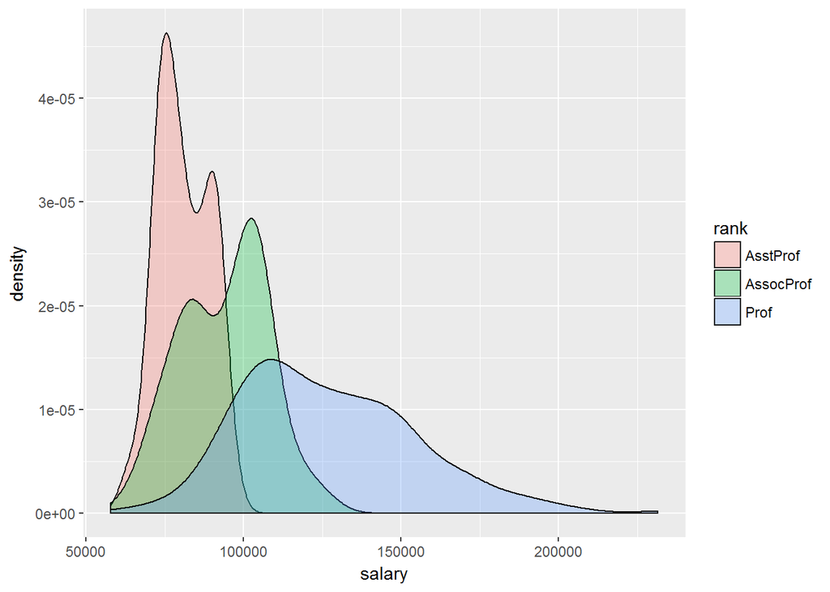

```r
data(Salaries,package = "car")
ggplot(Salaries,aes(x = salary,fill = rank)) +
  geom_density(alpha = .3)
```

图中的三条曲线表示不同的学术等级，颜色的使用提高了可视化，图例（legend）是自动产生的，后面会学到如何自定义分组数据的图例。 图中可以发现，薪水随着等级增长而增长，但是重叠比较明显，某些助教的公司与副教授或者教授的薪水相同。同时，随着学术等级增长，薪水的范围也在扩大。教授级别的公司尤其如此，收入差距非常大。

- 接下来通过性别和学术等级分组，绘制获得博士学位年数与薪水的关系：

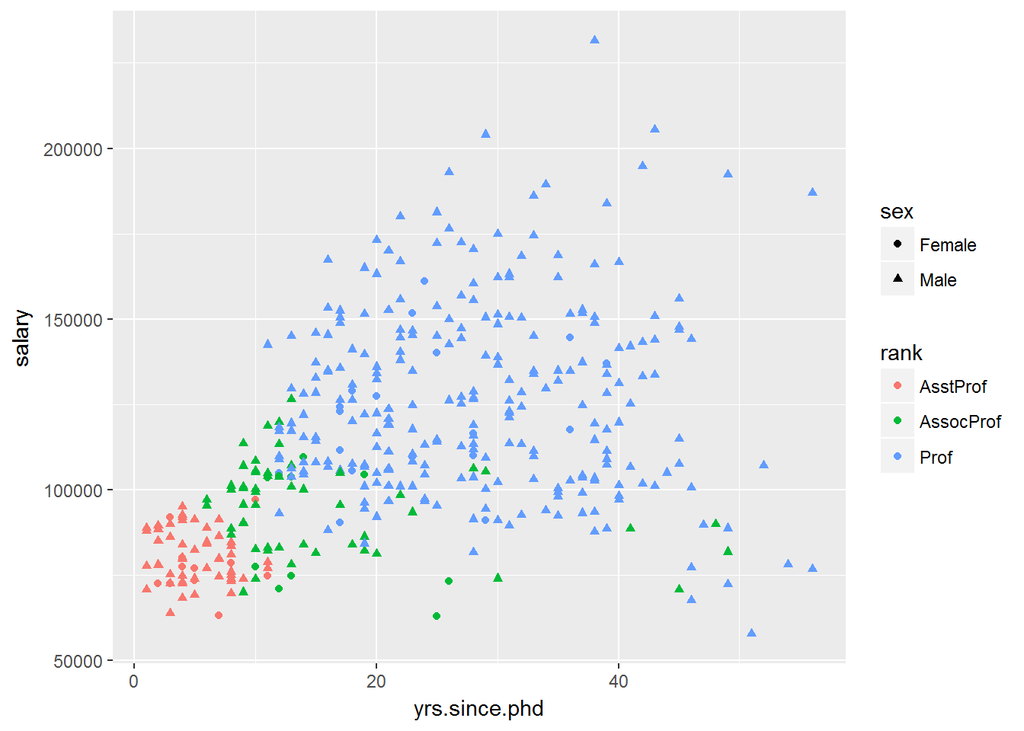

```r
ggplot(Salaries, aes(x = yrs.since.phd, y = salary, color = rank, shape = sex)) +
 geom_point()
```

从图中可以看出，薪水随着毕业年数的增加而增加，但绝对不是线性的增长关系

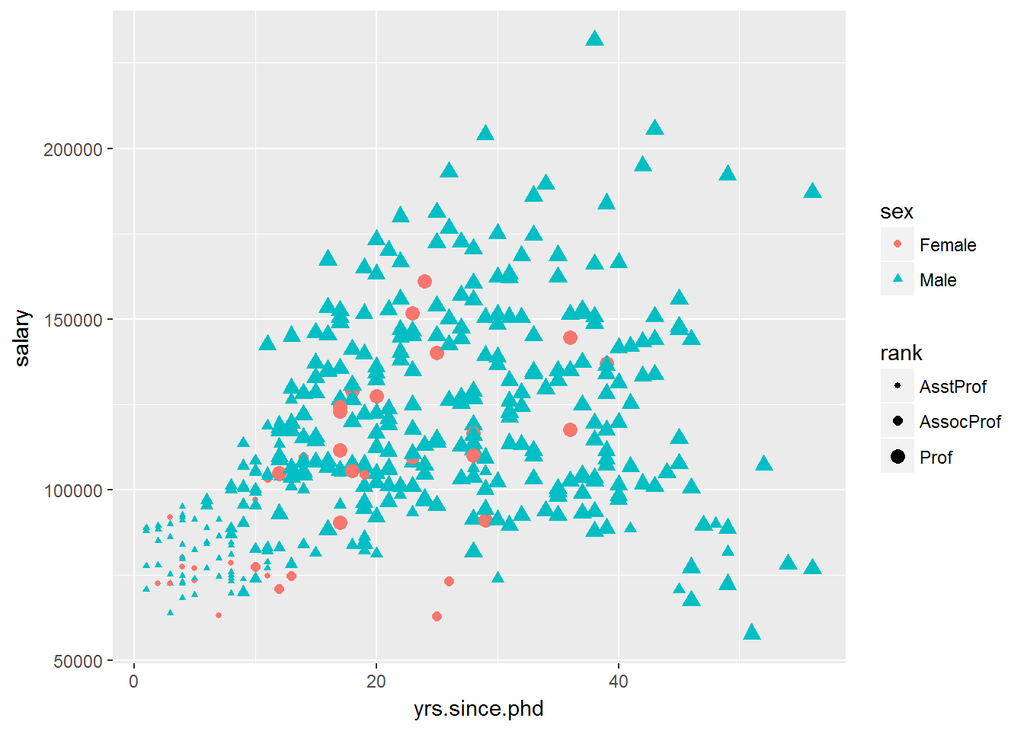

```r
data(Salaries,package = "car")
s=Salaries
ggplot(s) +
  aes( x = yrs.since.phd,
       y = salary,
       shape = sex,
       size = rank,
       color = sex) +
  # scale_shape_manual(values = c('o', '.')) +
  scale_size_manual(values=c(1,2,3)) +
  geom_point(show.legend = TRUE)
```

将颜色和形状用同一个变量sex来分组，并用尺寸表示rank的分组，可以很明显地发现，高收入高学历的女性是非常少的。

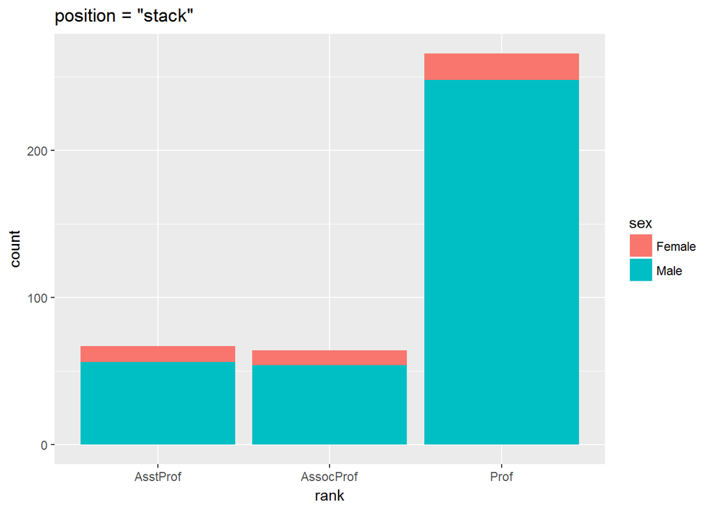

```r
ggplot(Salaries, aes(x = rank, fill = sex)) +
  geom_bar(position = "stack") +
  labs(title = 'position = "stack"')
```

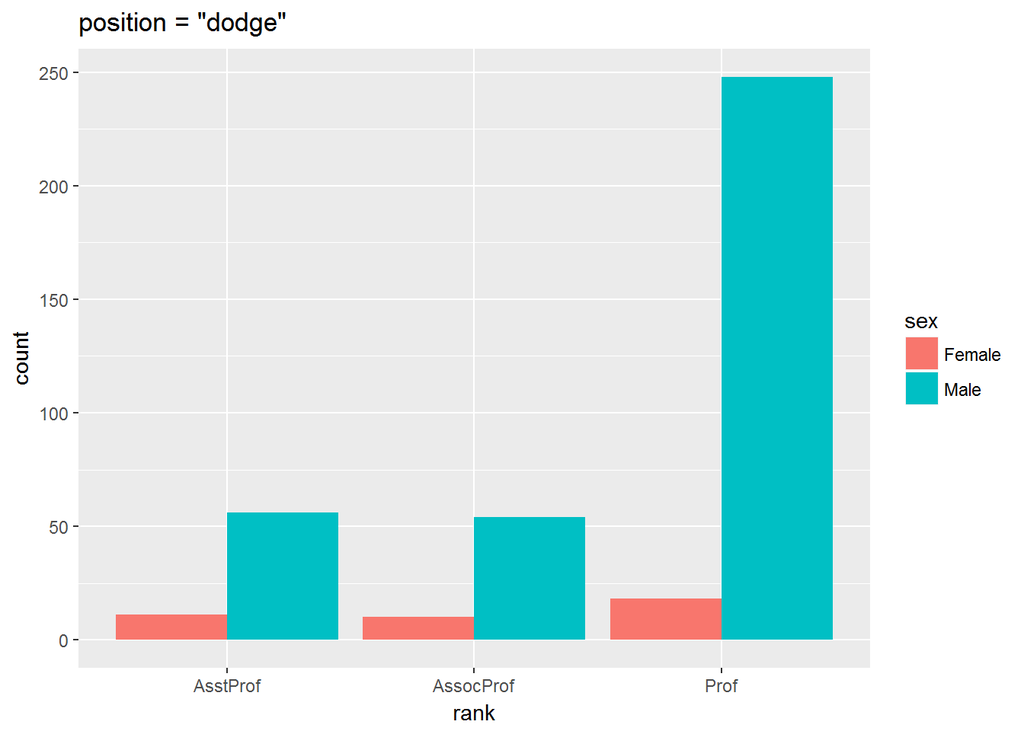

```r
ggplot(Salaries, aes(x = rank, fill = sex)) +
  geom_bar(position = "dodge") +
  labs(title = 'position = "dodge"')
```

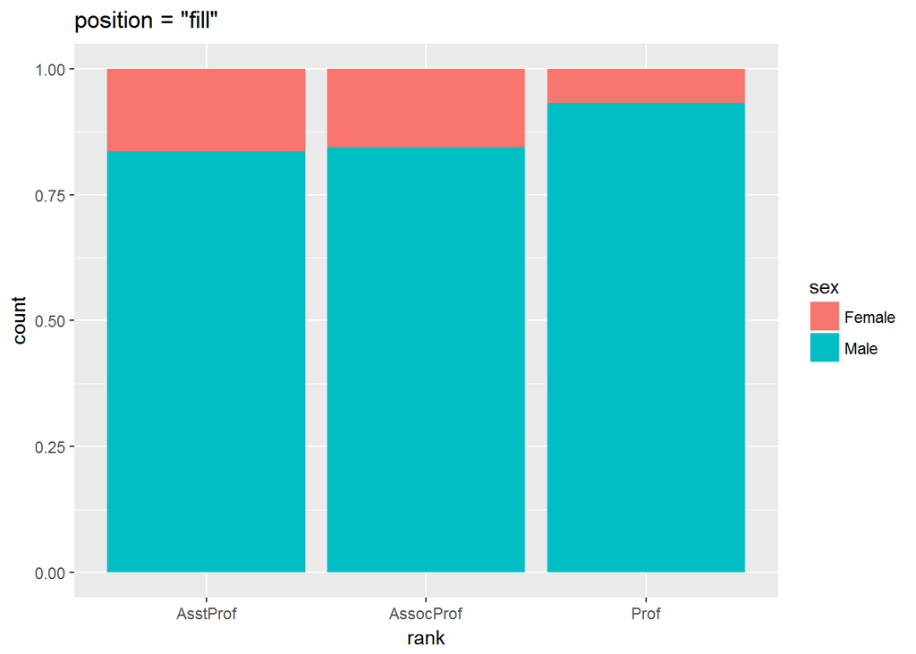

```r
ggplot(Salaries, aes(x = rank, fill = sex)) +
  geom_bar(position = "fill") +
  labs(title = 'position = "fill"')
```

分组条形图的三个版本，每个展示了按学术等级和性别划分的教授数量。 前两个图可以明显看出：教授的人数远大于其他学术等级的人数。女性教授的人数也比女助教和女副教多。 最后一张图可以看出，女教授的人数远远小于男教授的人数。

## 刻面

如果组在图中并排出现而不是重叠为单一的图形，关系就是清晰的。我们可以使用`facet_warp()`和`facet_grid`创建网格图型（也叫刻面图），如下为语法，其中var、rowvar和colvar是因子

| 语法 | 结果 |
| --- | --- |
| facet_warp(~var,ncol=n) | 将每个var水平排列成n列的独立图 |
| facet_warp(~var,nrow=n) | 将每个var水平排列成n行的独立图 |
| facet_grid(rowvar~colvar) | rowvar和colvar组合的独立图，其中rowvar表示行，colvar表示列 |
| facet_grid(rowvar~.) | 每个rowvar水平的独立图，配置成一个单列 |
| facet_grid(.colvar~) | 每个colvar水平的独立图，配置成一个单行 |

## 示例

```r
data(singer, packages = "lattice")
```

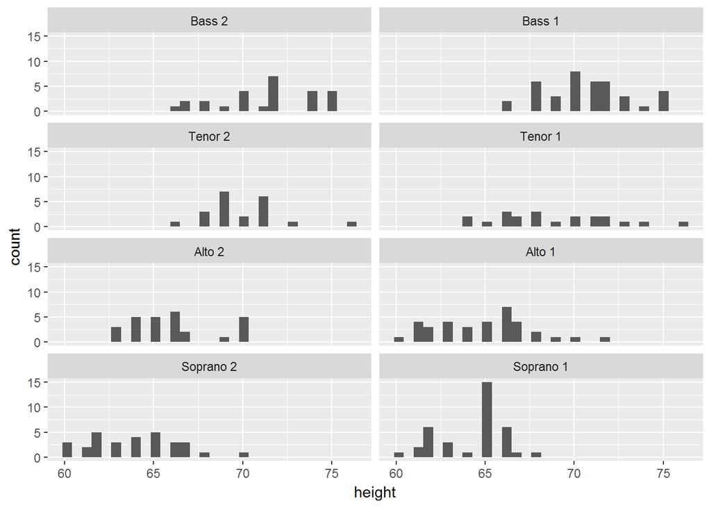

```r
ggplot (singer,aes(x = height)) +
         geom_histogram() +
         facet_wrap( ~ voice.part, nrow = 4)
```

得到了展示各声部歌手的身高分布图，把八个分部分为并排的小图可以方便比较

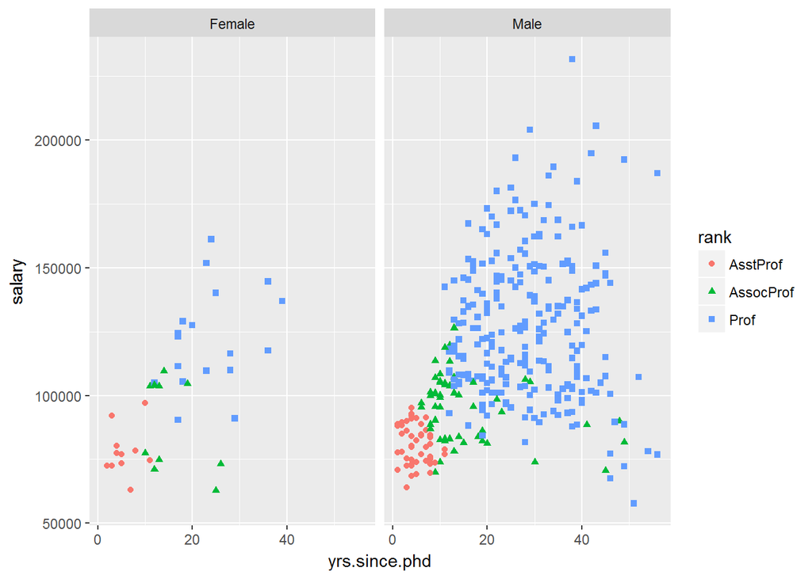

```r
ggplot(Salaries, aes(x = yrs.since.phd, y = salary, color = rank, shape = rank)) +
  geom_point() +
  facet_grid(.~sex)
```

结果展示了相同的信息，但是独立的刻面使其更容易理解

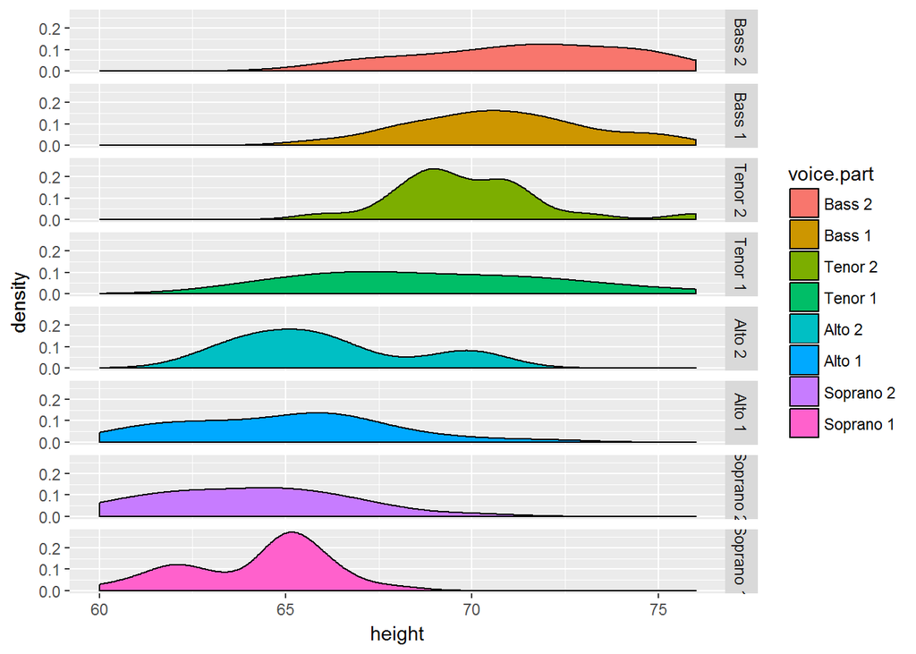

```r
ggplot(singer,aes(x = height, fill = voice.part)) +
  geom_density() +
  facet_grid(voice.part~.)
```

## 曲线

ggplot2包包含了一系列计算统计的函数来加到图形中。这些包括分级数据和计算密度、轮廓和分位数功能等。这一部分我们将着重分析一下添加平滑曲线（线性、非线性和非参数）到散点图中的方法。 使用geom_snooth()函数来添加一系列的平滑曲线和置信区域。带有置信区域的线性回归可以参考下图，函数的参数参见表

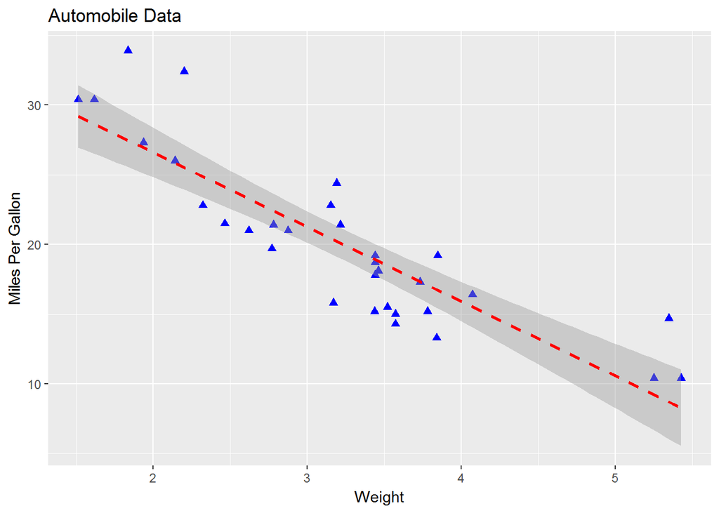

[output not shown]

```r
ggplot(data = mtcars,aes(x=wt,y=mpg)) +
  geom_point(pch = 17,color = "blue",size = 2) +
  geom_smooth(method = "lm", color = "red", linetype = 2) +
  labs(title = "Automobile Data", x = "Weight", y = "Miles Per Gallon")
```

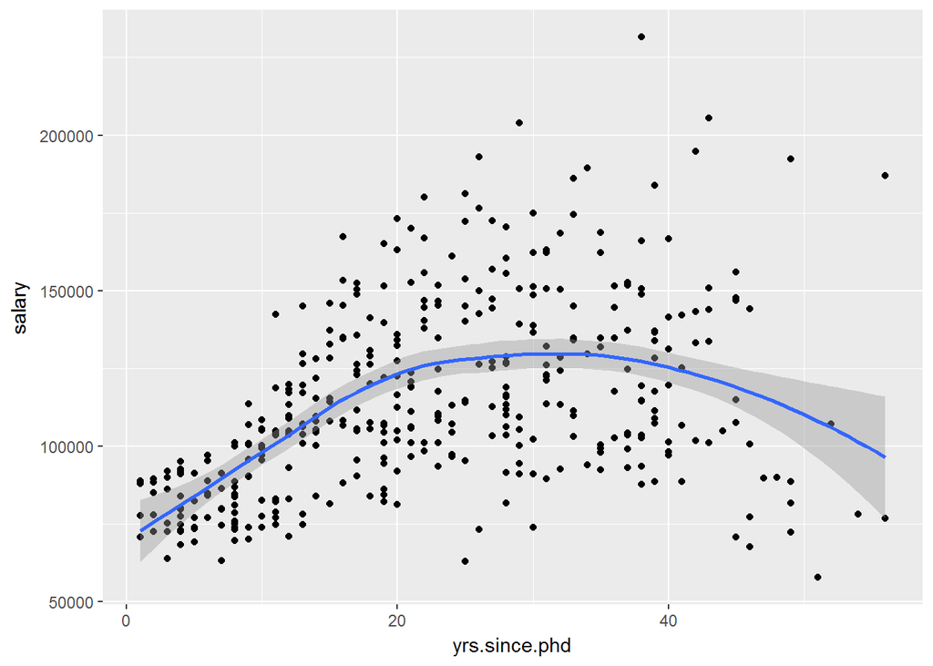

```r
ggplot(Salaries, aes(x = yrs.since.phd, y = salary)) +
  geom_point() +
  geom_smooth()
```

博士的毕业年数与薪水之间的关系，加上了以个带有95%置信区间的光滑曲线。该关系并不是线性的，至少在毕业时间很长的时候是这样的。

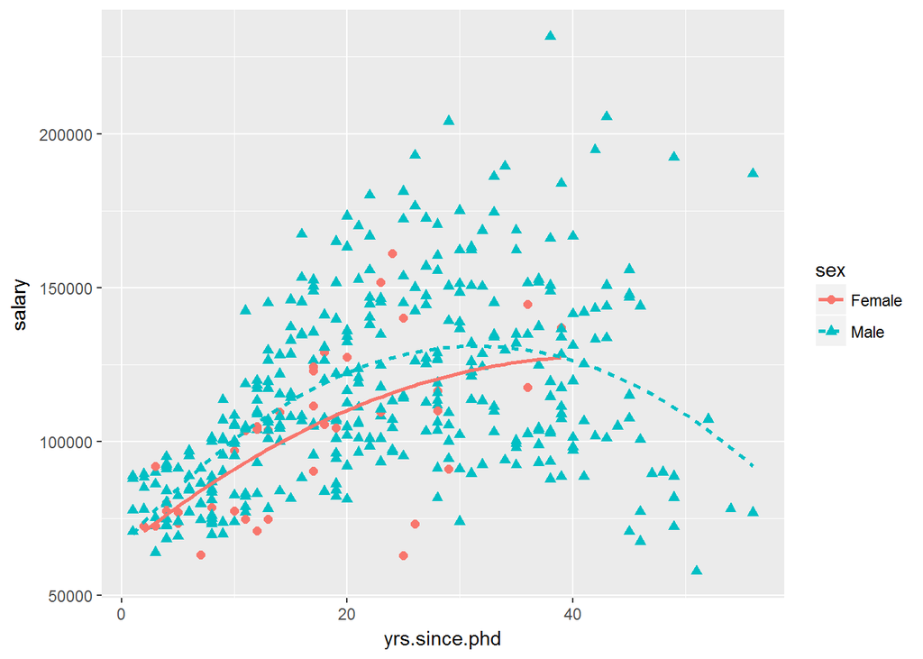

```r
       ggplot(Salaries, aes(x = yrs.since.phd, y =salary, color = sex, shape = sex, linetype = sex)) +
         geom_point(size = 2) +
         geom_smooth(method = lm, formula = y~poly(x,2), se = FALSE, size =1)
```

置信界限被FALSE来简化图，性别由颜色、符号、线条类型来区分. 对男性来说，曲线从0增加到30然后下降，对女性来说，拟合曲线从0到40年一直呈上升趋势。在数据集中，没有女性获得博士学位超过40年。对于数据集中的大部分范围，男性能拿到更高的薪水。

### 统计函数

ggplot2包中含有大量的统计函数来计算所需要的量，从而产生更多的可视化数据。通常情况下，几何函数隐式地调用统计函数，我们不需要直接处理这些问题，但是知道他们的存在是有用的。每个统计函数都有帮助页面，可以帮助我们了解几何函数是如何工作的。 例如，`geom_smooth`依赖于`stat_smooth`来计算画出一个拟合曲线及置信限所需的数量。在探索及和函数如何工作、哪些选项可供选择时，一定要去看这个函数以及相关统计函数的help文档。

## 修改图形的外观

本章节将使用几个函数来自定义ggplot2的图形外观，我们将学习如何自定义坐标轴的外观（范围、刻度和刻度标记标签），图例的位置和内容，变量值的颜色。同时也将学习如何创建特定的主题，为图形添加统一的外观和感觉，以及如何在一个图中管理几个子图。

### 坐标轴

ggplot2包会再创建图时自动创建刻度线、刻度标记标签和坐标轴标签。我们可以用`labs()`函数来添加标题并改变坐标轴标签，本节将自定义轴标签。

| 函数 | 选项 |
| --- | --- |
| sacle_x_continuous() sacle_y_continuous() | breaks=指定刻度标记,labels=指定刻度标记标签,limits=控制要展示的值的范围 |
| sacle_x_discrete() scale_y_discrete() | breaks=对因子的水平进行放置和排序,labels=指定这些水平的标签,limits=表示哪些水平应该展示 |
| coord_flip() | 颠倒x轴和y轴 |

可以看到，ggplot2的函数区分x轴和y轴，以及轴线是否代表一个连续或离散变量（因子）。让我们将这些函数应用到一个分组箱线图中，其中包含按学术等级和性别分组的薪资水平。

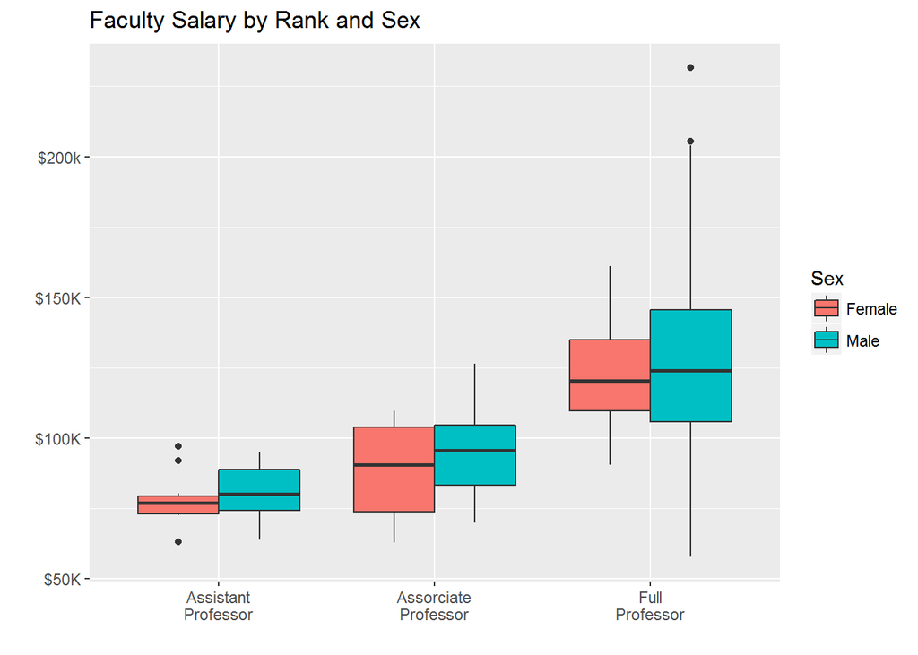

```r
ggplot(Salaries, aes(x = rank, y =salary, fill = sex)) + geom_boxplot() +
  scale_x_discrete( breaks = c("AsstProf", "AssocProf", "Prof"),
                    labels = c("Assistant\nProfessor", "Assorciate\nProfessor",
                               "Full\nProfessor")) +
  scale_y_continuous( breaks = c(50000,100000,150000,200000),
                      labels = c("$50K","$100K","$150K", "$200k")) +
  labs(title = "Faculty Salary by Rank and Sex",x = "", y = "",fill = "Sex" )
```

很明显，平均收入随着学术排名的上升而上升，在每个学术等级中男性的薪资水平高于女性。 （可以试着控制博士学位的年数，获得一个更完整的图像）

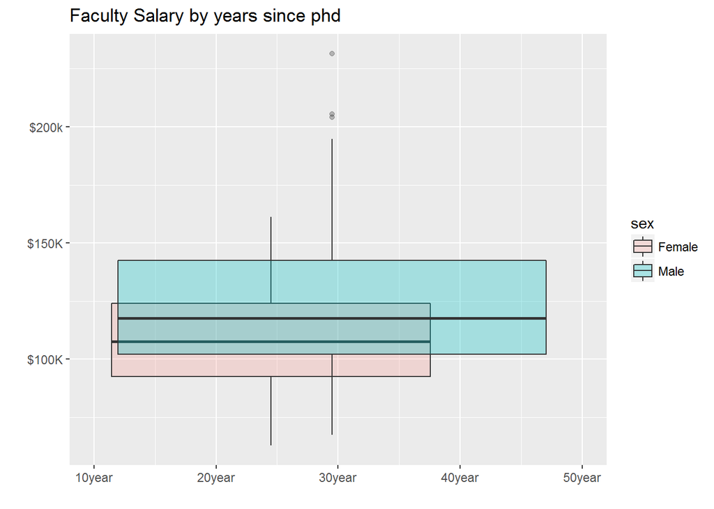

```r
ggplot(Salaries, aes(x = yrs.since.phd, y =salary, fill = sex,alpha = sex)) + geom_boxplot() +
  scale_x_continuous( breaks = c(10,20,30,40,50),
                    labels = c("10year", "20year",
                               "30year","40year","50year"),
                    limits = c(10,50)) +
  scale_y_continuous( breaks = c(50000,100000,150000,200000),
                      labels = c("$50K","$100K","$150K", "$200k")) +
  labs(title="Faculty Salary by years since phd", x = "", y = "") +
  scale_alpha_discrete(range = c(.2,.3))
```

### 图例

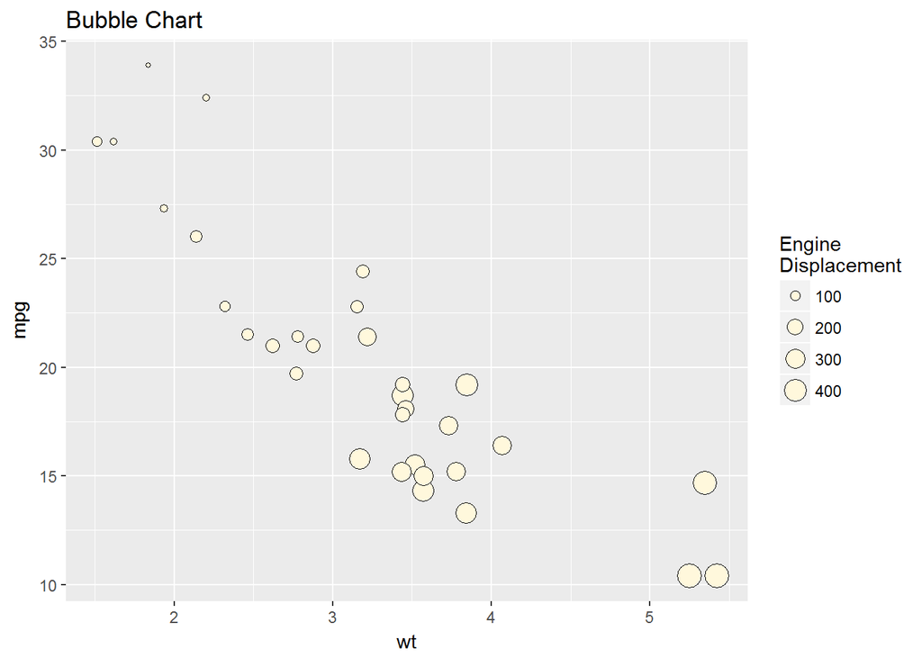

```r
ggplot(data = mtcars,aes(x=wt,y=mpg,size = disp)) +
  geom_point(shape = 21,color = "black",fill = "cornsilk") +
  labs(title = "Bubble Chart", size = "Engine\nDisplacement")
```